# 의사결정나무 기반 상품 리뷰 감정 분류

## 1. 배경

- 전자 상거래의 발전, 휴대폰의 대중화 및 물류 시스템의 개선으로 온라인 쇼핑은 사람들의 삶의 일부가 되었다.많은 사용자가 쇼핑몰에서 구매한 제품에 대해 자신의 의견을 발표하여 대량의 상품 리뷰 데이터를 생성했다.이러한 상품 리뷰 데이터를 수집, 분석 및 처리하는 것은 매우 중요하다.
- 소비자의 경우 이 데이터를 통해 제품의 품질을 더 잘 이해할 수 있으며 제품 선택에 도움이 되다.
- 사업자의 경우 이 데이터를 통해 제품에 대한 소비자의 만족도를 더 잘 이해할 수 있으며, 이는 제품 품질을 개선하고 더 나은 마케팅 전략을 선택하는 데 도움이 되다.
- 인터넷 쇼핑몰의 경우 이를 통해 여론의 성향을 더 잘 파악할 수 있어 갑작스러운 상황 발생 시 보다 즉각적인 조치를 취할 수 있다.

## 2. 데이터

- 언어: 중국어
- 출처: WWW.JD.COM
- 수량: 63402
- Label: 1: 긍정적 0: 부정적

```python
DataFrame=pd.read_excel("상품리뷰 데이터셋 (중복제거).xlsx")
DataFrame
```

|  | review | label |
| --- | --- | --- |
| 0 | 做父母一定要有刘墉这样的心态，不断地学习，不断地进步，不断地给自己补充新鲜血液，让自己保持... | 1 |
| 1 | 作者真有英国人严谨的风格，提出观点、进行论述论证，尽管本人对物理学了解不深，但是仍然能感受到... | 1 |
| 2 | 作者长篇大论借用详细报告数据处理工作和计算结果支持其新观点。为什么荷兰曾经县有欧洲最高的生产... | 1 |
| 3 | 作者在战几时之前用了＂拥抱＂令人叫绝．日本如果没有战败，就有会有美军的占领，没胡官僚主义的延... | 1 |
| 4 | 作者在少年时即喜阅读，能看出他精读了无数经典，因而他有一个庞大的内心世界。他的作品最难能可贵... | 1 |
| ... | ... | ... |
| 63397 | 非常满意，是正品。安装的也很漂亮！ | 1 |
| 63398 | 热水器很好用啦， | 1 |
| 63399 | 已经是第三次购买了 很好的 第一次是给自己买 自己用的很好，所以给婶婶也推荐了 ... | 1 |
| 63400 | 热水器很漂亮，而且比实体店实惠多了。配的配件齐全，安装后使用了一下，加热很快。超赞！ | 1 |
| 63401 | 东西还不错 自己装起来了 希望能用久点 | 1 |

63402 rows × 2 columns

### 2.1 데이터 클리닝

- 주요 내용은 영문 숫자 구두점을 제거하고.어절 분활 ,품사 표시한후에 불용어를 제거하고 테이블을 생성하다. 여기에는 중국어 텍스트 분석을 위한 jieba라는 라이브러리가 사용되다. -다음은 코드:
- clean 숫자, 영문자 제거

```python
Series_댓글내용=DataFrame['review']
info=re.compile('[0-9a-zA-Z]')
Series_댓글내용=Series_댓글내용.apply(lambda x: info.sub('',str(x)))
```

- 어절분활/품사표식

```python
Series_단어=Series_댓글내용.apply( lambda s:  [(x.word,x.flag) for x in psg.cut(s)] )
Series_단어
```

```
Building prefix dict from the default dictionary ...
Loading model from cache C:\Users\ADMINI~1\AppData\Local\Temp\jieba.cache
Loading model cost 0.607 seconds.
Prefix dict has been built successfully.
```

```
0        [(, x), (做, v), (父母, n), (一定, d), (要, v), (有,...
1        [(作者, n), (真, d), (有, v), (英国人, nz), (严谨, a), ...
2        [(作者, n), (长篇大论, l), (借用, v), (详细, ad), (报告, n...
3        [(作者, n), (在, p), (战, n), (几时, d), (之前, f), (用...
4        [(作者, n), (在, p), (少年, m), (时即, d), (喜, v), (阅...
                               ...
63397    [(非常, d), (满意, v), (，, x), (是, v), (正品, n), (。...
63398    [(热水器, n), (很, d), (好用, v), (啦, y), (，, x), ( ...
63399    [(已经, d), (是, v), (第三次, m), (购买, v), (了, ul), ...
63400    [(热水器, n), (很漂亮, n), (，, x), (而且, c), (比, p), ...
63401    [(东西, ns), (还, d), (不错, a), ( , x), ( , x), ( ...
Name: review, Length: 63402, dtype: object
```

- 단어수를 찾아 보다

```python
Series_단어수=Series_단어.apply(lambda s: len(s))
Series_단어수
```

```
0        160
1        117
2         85
3        102
4        121
        ...
63397     11
63398      6
63399    144
63400     27
63401     23
Name: review, Length: 63402, dtype: int64
```

- 분사표를 만들다

```python
#인덱스 위치
list_인덱스=[[x+1]*y for x,y in zip(list(Series_단어.index),list(Series_단어수))]
list_인덱스=sum(list_인덱스,[])
```

```python
#단어_품사
list_단어_품사=sum(Series_단어,[])
```

```python
#단어_품사
list_단어=[x[0] for x in list_단어_품사]
list_품사=[x[1] for x in list_단어_품사]
```

```python
#data2만들
list_라벨=[ [x]*y for x,y in zip(list(DataFrame['label']),list(Series_단어수))] #[x+1]*y,表示复制y份
list_라벨=sum(list_라벨,[])
DataFrame2=pd.DataFrame({'인덱스':list_인덱스,
                        '단어':list_단어,
                        '품사':list_품사,
                        '라벨':list_라벨})
```

```python
#구두점 제거
DataFrame2=DataFrame2[DataFrame2['품사']!='x']
```

```python
stop_path=open('./stoplist.txt','r',encoding='UTF-8')
stop_words=stop_path.readlines()
stop_words=[word.strip('\n') for word in stop_words]
list_NOstopword=list(set(list_단어)-set(stop_words))
DataFrame2=DataFrame2[DataFrame2['단어'].isin(list_NOstopword)]
DataFrame2
```

|  | 인덱스 | 단어 | 품사 | 라벨 |
| --- | --- | --- | --- | --- |
| 1 | 1 | 做 | v | 1 |
| 2 | 1 | 父母 | n | 1 |
| 6 | 1 | 刘墉 | nr | 1 |
| 9 | 1 | 心态 | n | 1 |
| 13 | 1 | 学习 | v | 1 |
| ... | ... | ... | ... | ... |
| 2409731 | 63402 | 装 | v | 1 |
| 2409738 | 63402 | 希望 | v | 1 |
| 2409739 | 63402 | 能用 | v | 1 |
| 2409740 | 63402 | 久 | a | 1 |
| 2409741 | 63402 | 点 | q | 1 |

985689 rows × 4 columns

- 👆985689개의 단어가 포함된 표 한 장을 생성했다 여기서 `인덱스` 열은 단어가 원래 속한 대글의 위치를 표식하기위해 만들었다.
- 특징 추출 단계에서 주로 단어를 벡터로 변환하고 one-hot encoding 이다.

```python
#피쳐 공간 및 레이블 만들기
Y=[]
for ind in DataFrame2.인덱스.unique():
    y=[ word for word in DataFrame2.라벨[DataFrame2.인덱스==ind].unique() ]
    Y.append(y)
X=[]
for ind in DataFrame2.인덱스.unique():
    term=[ word for word in DataFrame2.단어[DataFrame2.인덱스==ind].values ]
    X.append(' '.join(term))
```

```python
#훈련 세트, 테스트 만들기,20%
x_train,x_test,y_train,y_test=train_test_split(X,Y,test_size=0.2,random_state=7)
#원-핫 인코딩(One-Hot Encoding)
count_vec=CountVectorizer(binary=True,decode_error="replace")
x_train=count_vec.fit_transform(x_train)
x_test=count_vec.transform(x_test)
```

## 3.의사결정 나무 모델

- 의사결정 나무 모델 깊이가 163일 때 훈련 세트의 정확도는 95%, 테스트 세트의 정확도는 82%였습니다.

```python
# Decision Tree
dtc=tree.DecisionTreeClassifier(max_depth=163)
dtc.fit(x_train,y_train)
print('Training Set정확도：%.2f'% accuracy_score(y_train,dtc.predict(x_train)))
y_true=y_test
y_pred=dtc.predict(x_test)
print(classification_report(y_true,y_pred))
print('Test Set정확도：%.2f'% accuracy_score(y_true,y_pred))
```

```
Training Set정확도：0.95
              precision    recall  f1-score   support

           0       0.80      0.85      0.82      6298
           1       0.84      0.79      0.81      6360

    accuracy                           0.82     12658
   macro avg       0.82      0.82      0.82     12658
weighted avg       0.82      0.82      0.82     12658

Test Set정확도：0.82
```

## 4.모델 최적화 방안

- 반복적인 테스트 후에 의사결정 나무의 깊이가 약 50일 때 모델 정확도가 80%에 도달한다는 것을 발견하다. 깊이가 50 이상인 후 모델 정확도는 80%에서 82% 사이로 유지되다. 따라서 모델의 최적화가 임계값에 도달했다고 판단되며 정확도를 계속 향상시킬 수 없다.깊이가 163일 때 정확도가 82%로 가장 높습니다.따라서 최종 깊이가 163인 모델을 선택하여 저장함다.
- 모델 최적화의 핵심 코드는 다음과 같다.최적화의 주요 방법은 매개변수 `max_depth`를 수정하여 의사결정 트리를 재구성하여 다양한 깊이 결정 트리의 정확도를 비교하는 것이다.

```
for depth in range(1,250):
    dtc=tree.DecisionTreeClassifier(max_depth=depth)
    dtc.fit(x_train,y_train)
    y_true=y_test
    y_pred=dtc.predict(x_test)
    print('depth:'+str(depth)+',정확도：%.2f'% accuracy_score(y_true,y_pred))
```

## 5. 모델평가

[output not shown]

- 의사결정 나무 모델의 예측 정확도는 0.82로 테스트 세트의 82% 샘플이 올바르게 분류되었음을 나타낸다.
- Precision는 0.82로, 예측된 True샘플 중 True Positive 샘플의 비율이 82%임을 나타낸다.
- Recall는 0.82로 예측된 TruePositive샘플 중 예측이 정확한 샘플의 비율이 82%임을 나타낸다.
- F-socre는 정확도와 회수율을 종합적으로 평가한 지표로 0.82다.
- ROC 곡선은 왼쪽 상단에서 멀리 떨어져 있으며,AUC 값은 0.81다. 전반적으로 의사 결정 나무 모델은 예측 효과가 있지만 여전히 개선의 여지가 있다.

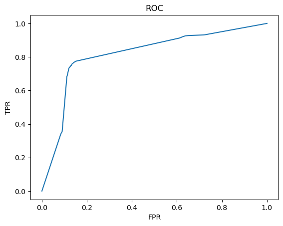

```python
plt.plot(fpr,tpr)
plt.xlabel('FPR')
plt.ylabel('TPR')
plt.title('ROC')
plt.show()
```

```python
roc_auc_score(y_test,y_pred_proba[:,1])
```

```
0.8165388058702874
```

## 6.결론

- "기계학습 텍스트 감성 분석에 기반한 상품 평가 분류" 이 목표으로 의사결정 나무 알고리즘에 기반한 제품 평가 감겅분류 모델의 구축과 평가하다.
- 매개변수 max_depth를 수정하여 의사 결정 트리를 재구성하고 깊이가 다른 의사 결정 트리의 정확도를 비교한 결과 깊이 163의 모델이 더 나은 성능을 가지고 있음을 발견니다. 따라서 이 매개변수를 최적화하면 모델의 예측 효과가 더욱 향상되다.
- 사용된 모델 외에도 K-nn, 소박한 베이지안 알고리즘, 선형 회귀 알고리즘 및 K-means 알고리즘과 같은 다른 기계 학습 알고리즘에 대한 논문을 조사했다. 이들 중 대부분 알고리즘은 프로젝트에 사용되지 않았지만 배우면서 귀중한 수확으로 남아 있다.
- 충분한 모델을 시도하지 않다. 다른 모델의 효과를 비교하기 위해 더 많은 모델을 시도해야 하다. 그리고 모델의 정확도는 82% 정도로 높지 않다. 현재 최고의 딥러닝 알고리즘으로 텍스트 감정 분석의 정확도는 95%를 초과할 수 있지만 제한된 능력으로 인해 최고의 우수한 알고리즘 수준에 도달하지 못하다. 관련 논문을 읽고 알고리즘 아이디어를 이해하는 것이 어려웠고, 더 나은 알고리즘을 재현하지 못했다.